# a4_task2_nikole_vannest

Nikole Vannest

11/17/2020

## Data and analyses

In this study I will explore observed juvenile snowshoe hares over the years, utilizing an exploratory histogram as well as summary statistics to interpret my findings. I compare weight across sex and site, utilizing a beeswarm and boxplot with summary statistics as well to validate the information that is being presented. I also modelled hind foot length against weight, utilizing exploratory histogram and qqplots, as well as a linear model, t-test, Cohen’s d test, and Pearson’s r correlation. These statistical methods were used and interpreted to emphasize the significance of the information that is being presented here.

## Exploratory findings

**Table 1.** Descriptive statistics of the total observations per year of juvenile snowshoe hares. Data: Kielland et. al. (2017).

| Mean count per year | Median count per year | Standard deviation | Maximum per year | Minimum per year |
| --- | --- | --- | --- | --- |
| 31.5 | 18.5 | 35.88492 | 126 | 2 |

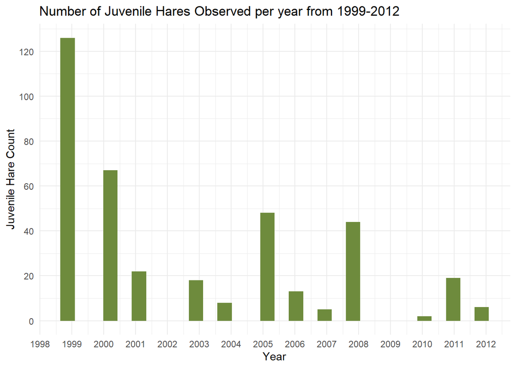

**Figure 1.** Visual representation of the total number of observed juvenile hares from 1999 to 2012. The y axis depicts juvenile snowshoe hare count, with each year represented on the x axis. Data: Kielland et. al. (2017).

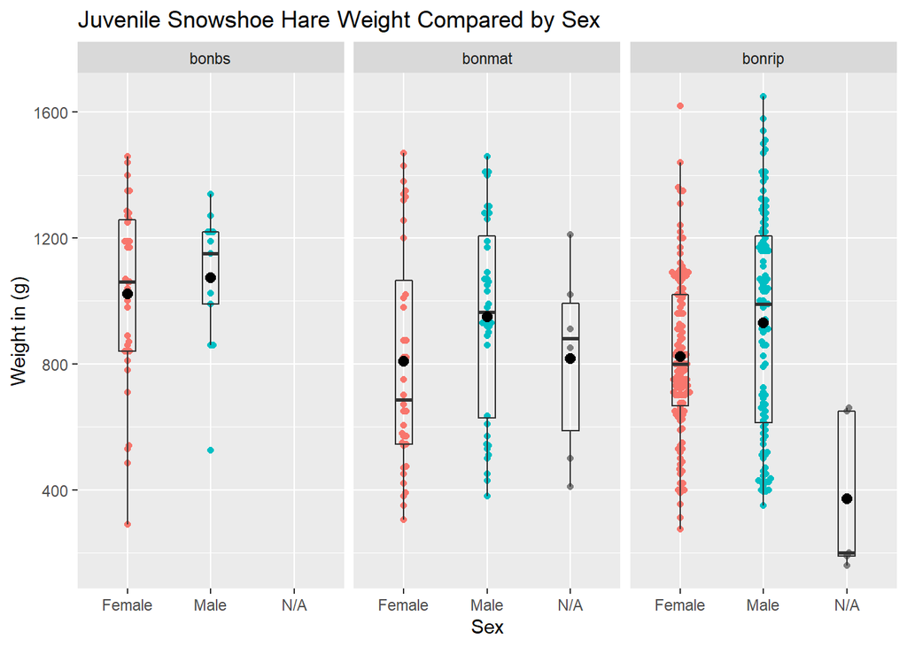

**Figure 2.** Juvenile snowshoe hare weight compared by sex across three sites. Weight in () is depicted on the y axis and visual separation by sex type on the x axis. There is a third category for N/A results included. The black point within the boxplots indicate the mean, and black line indicates the median value for each group. The end line of each box indicates the 25th and 75th percentile values, with the upper and lower whiskers indicating variability outside the upper and lower quartiles and outliers as individual points. Data: Kielland et. al. (2017).

**Major Takeaways** Mean and median values of within site comparison of male and female weights shows female weight tend to be slightly lower than male weights across all sites (female = 855.39, 825) as compared to male = (945.86, 990). Sample sizes were much larger in bonrip than other sites (male = 110, female = 129) compared to bonmat (male = 40, female = 36) and bonbs (male = 13, female = 35). NA values have a smaller sample size and are inconclusive, with no NA observations in bonbs.

**Table 2.** Comparing juvenile snowshoe hare weights between male and female groups with summary statistics including mean and standard deviation of weight across both sexes, and number of observations.

| Sex | Mean weight | Median weight | Standard deviation | Count |
| --- | --- | --- | --- | --- |
| f | 855.39 | 825 | 292.25 | 200 |
| m | 945.86 | 990 | 333.22 | 163 |
| NA | 614.55 | 650 | 357.59 | 15 |

**Major takeaways** On average observed female juvenile snowshoe hare weights are less than that of observed male weights. The difference in means between male and female hares (90.47) in (g). Cohen’s D effect size is very low (-0.2904674), and t-test give a p-value of (0.0070933). With the given statistics, we can safely reject the null hypothesis and assume male and female weights are significantly different groups.

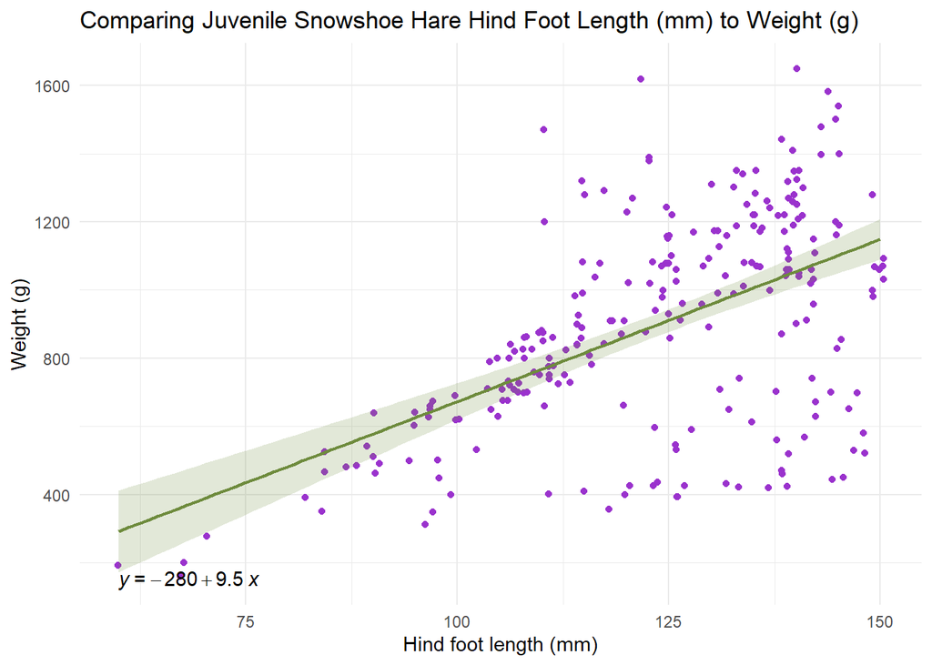

**Figure 3.** Juvenile snowshoe hare hind foot length in (mm) compared to weight (g) in purple. Green line depicts a linear regression model with a slope of -280 + 9.5x; the shading representing a 95% confidence interval. Data: Kielland et. al. (2017).

**Major Takeaways** Juvenile snowshoe hare hind foot length and weight are positively correlated with an R<sup>2</sup> value of (0.299), a p-value of (8.45836810^{-21}), and a Pearson’s r correlation value of (0.547). Although our p-value is significant and Pearson’s correlation value moderately correlated, we can see visually from the graph that the data points become more spread out as hind foot length and weight increases. Purely from visual interpretation, I would expect the strength of the linear model to explain trends in the data to be less significant as weight and hind foot length increase.

## Citations

Kielland, K., F.S. Chapin, R.W. Ruess, and Bonanza Creek LTER. 2017. Snowshoe hare physical data in Bonanza Creek Experimental Forest: 1999-Present ver 22. Environmental Data Initiative.